# Introducción

El siguiente es un caso de estudio extraído del Programa de Análisis de Datos de Google, realizado sobre Bellabeat, una empresa ficticia de gadgets de salud focalizada en mujeres.

Dichos archivos, junto con todo el presente código y documentación respectiva también se encuentran disponibles en el [repositorio de Github](https://github.com/martinmalandra/Cyclistics-v2) de este proyecto.

# Presentación del caso - Bellabeat

Urška Sršen y Sando Mur fundaron Bellabeat, una empresa de alta tecnología que fabrica productos inteligentes centrados en la salud. Sršen aprovechó su formación como artista para desarrollar tecnología de diseño atractivo que informa e inspira a mujeres de todo el mundo. La recopilación de datos sobre actividad, sueño, estrés y salud reproductiva ha permitido a Bellabeat dotar a las mujeres de conocimientos sobre su propia salud y sus hábitos. Desde su fundación en 2013, Bellabeat ha crecido rápidamente y se ha posicionado rápidamente como una empresa de bienestar impulsada por la tecnología para las mujeres.

En 2016, Bellabeat había abierto oficinas en todo el mundo y lanzado múltiples productos. Los productos de Bellabeat pasaron a estar disponibles a través de un número creciente de minoristas en línea, además de su propio canal de comercio electrónico en su sitio web. La empresa ha invertido en medios publicitarios tradicionales, como radio, vallas publicitarias exteriores, prensa y televisión, pero se centra ampliamente en el marketing digital. Bellabeat invierte durante todo el año en la búsqueda de Google, mantiene activas sus páginas de Facebook e Instagram e interactúa constantemente con los consumidores en Twitter. Además, Bellabeat publica anuncios de vídeo en Youtube y anuncios en la Red de Display de Google para apoyar campañas en fechas clave de marketing. Sršen sabe que un análisis de los datos de consumo disponibles de Bellabeat revelaría más oportunidades de crecimiento. Ha pedido al equipo de análisis de marketing que se centre en un producto de Bellabeat y analice los datos de uso de los dispositivos inteligentes para saber cómo los utilizan los usuarios. A partir de esta información, le gustaría recibir recomendaciones de alto nivel sobre cómo estas tendencias pueden influir en la estrategia de marketing de Bellabeat.

## Escenario de análisis

Sršen está interesada en analizar los datos de uso de los dispositivos inteligentes para comprender mejor cómo utilizan los consumidores los dispositivos inteligentes que no son de Bellabeat. A continuación, solicitará seleccionar un producto Bellabeat al que aplicar estos conocimientos en la presentación. Las preguntas que guian este análisis:

- ¿Cuáles son algunas tendencias en el uso de dispositivos smart?
- ¿Cómo se podrían aplicar estas tendencias a los usuarios de Bellabeat?
- ¿Cómo podrían estas tendencias ayudar a influenciar la estrategia de Marketing de Bellabeat?

# Business task

Se identifica entonces la tarea clave para el análisis: identificar tendencias en los sets de datos producido por un dispositivo de la marca sobre el cual entender mejor los hábitos y necesidades por parte de los usuarios y generar posibles estrategias de marketing.

# Datos a emplear

Se dispone de un set de archivos CSV de uso público, disponibles en el siguiente [link](https://www.kaggle.com/datasets/arashnic/fitbit).

Se procede entonces a descargar y organizar los datos de manera local.

## Preparación de entorno y herramientas utilizadas

Para el siguiente proceso, utilizaremos R Studio IDE, en conjunto con los siguientes paquetes:

- Tidyverse
- Lubridate
- Hms

```r
library(tidyverse)
library(lubridate)
library(hms)
```

## 1. Exploración de los archivos y los datos

Disponibles en unidad días se encuentran:

- Actividad
- Calorías
- Intensidades
- Pasos
- Sueño

Disponibles en unidad horas se encuentran:

- Calorías
- Intensidades
- Pasos

Disponibles en unidad minutos se encuentran:

- Calorías
- Intensidades (en formato angosto y ancho, es decir con trasposición de filas y columnas)
- Pasos (ancho y angosto)
- MET (equivalente metabólico de tarea o por sus siglas en inglés, metabolic equivalent of task)

Disponible en unidad segundos se encuentra:

- Pulso cardíaco

Y por último, sin unidad relativa, se encuentra el registro de peso.

Para el siguiente análisis, elegimos trabajar con los estos sets de datos:

- Por un lado, usaremos los datos condensados en un set llamado ‘dailyActivity_merged.csv’ sobre el cual identificaremos las tendencias de uso de los usuarios, observando como varían el consumo calórico y la distancia a lo largo del mes observado, y si estas se encuentran relacionadas entre sí.
- Por el otro, veremos la actividad física de los usuarios a lo largo de la semana y a lo largo de un mismo día, para identificar cuales son los momentos de mayor actividad física a lo largo de un día y de una semana de uso.

### A. Primer set de datos: datos condensados

#### 1. Orden y limpieza

Daremos un vistazo al archivo csv correspondiente con:

```r
glimpse(read.csv("dailyActivity_merged.csv"))
```

```
## Rows: 940
## Columns: 15
## $ Id                       <dbl> 1503960366, 1503960366, 1503960366, 150396036…
## $ ActivityDate             <chr> "4/12/2016", "4/13/2016", "4/14/2016", "4/15/…
## $ TotalSteps               <int> 13162, 10735, 10460, 9762, 12669, 9705, 13019…
## $ TotalDistance            <dbl> 8.50, 6.97, 6.74, 6.28, 8.16, 6.48, 8.59, 9.8…
## $ TrackerDistance          <dbl> 8.50, 6.97, 6.74, 6.28, 8.16, 6.48, 8.59, 9.8…
## $ LoggedActivitiesDistance <dbl> 0, 0, 0, 0, 0, 0, 0, 0, 0, 0, 0, 0, 0, 0, 0, …
## $ VeryActiveDistance       <dbl> 1.88, 1.57, 2.44, 2.14, 2.71, 3.19, 3.25, 3.5…
## $ ModeratelyActiveDistance <dbl> 0.55, 0.69, 0.40, 1.26, 0.41, 0.78, 0.64, 1.3…
## $ LightActiveDistance      <dbl> 6.06, 4.71, 3.91, 2.83, 5.04, 2.51, 4.71, 5.0…
## $ SedentaryActiveDistance  <dbl> 0, 0, 0, 0, 0, 0, 0, 0, 0, 0, 0, 0, 0, 0, 0, …
## $ VeryActiveMinutes        <int> 25, 21, 30, 29, 36, 38, 42, 50, 28, 19, 66, 4…
## $ FairlyActiveMinutes      <int> 13, 19, 11, 34, 10, 20, 16, 31, 12, 8, 27, 21…
## $ LightlyActiveMinutes     <int> 328, 217, 181, 209, 221, 164, 233, 264, 205, …
## $ SedentaryMinutes         <int> 728, 776, 1218, 726, 773, 539, 1149, 775, 818…
## $ Calories                 <int> 1985, 1797, 1776, 1745, 1863, 1728, 1921, 203…
```

En primera instancia notamos dos limitaciones importantes: las fechas se encuentran formateadas como caracteres de manera ambigua siguiendo el esquema ‘mes/día/año’. A su vez, los Identificadores de usuario (Id) están formateados como números, cuando es ideal tenerlos como variables categóricas, es decir, factor.

Antes de llegar al proceso de formato, cargaremos nuestro set de datos en una variable de entorno.

```r
Actividad_D <- read.csv("dailyActivity_merged.csv")
```

```r
str(Actividad_D)
```

```
## 'data.frame':    940 obs. of  15 variables:
##  $ Id                      : num  1.5e+09 1.5e+09 1.5e+09 1.5e+09 1.5e+09 ...
##  $ ActivityDate            : chr  "4/12/2016" "4/13/2016" "4/14/2016" "4/15/2016" ...
##  $ TotalSteps              : int  13162 10735 10460 9762 12669 9705 13019 15506 10544 9819 ...
##  $ TotalDistance           : num  8.5 6.97 6.74 6.28 8.16 ...
##  $ TrackerDistance         : num  8.5 6.97 6.74 6.28 8.16 ...
##  $ LoggedActivitiesDistance: num  0 0 0 0 0 0 0 0 0 0 ...
##  $ VeryActiveDistance      : num  1.88 1.57 2.44 2.14 2.71 ...
##  $ ModeratelyActiveDistance: num  0.55 0.69 0.4 1.26 0.41 ...
##  $ LightActiveDistance     : num  6.06 4.71 3.91 2.83 5.04 ...
##  $ SedentaryActiveDistance : num  0 0 0 0 0 0 0 0 0 0 ...
##  $ VeryActiveMinutes       : int  25 21 30 29 36 38 42 50 28 19 ...
##  $ FairlyActiveMinutes     : int  13 19 11 34 10 20 16 31 12 8 ...
##  $ LightlyActiveMinutes    : int  328 217 181 209 221 164 233 264 205 211 ...
##  $ SedentaryMinutes        : int  728 776 1218 726 773 539 1149 775 818 838 ...
##  $ Calories                : int  1985 1797 1776 1745 1863 1728 1921 2035 1786 1775 ...
```

Procedemos a formatear la variable ActivityDate como fecha:

```r
Actividad_D <- Actividad_D %>%
  mutate(ActivityDate = mdy(ActivityDate))
```

Luego formateamos el Id como variable categórica (Factor)

```r
Actividad_D <- Actividad_D %>%
  mutate(Id = factor(Id))
```

```r
str(Actividad_D)
```

```
## 'data.frame':    940 obs. of  15 variables:
##  $ Id                      : Factor w/ 33 levels "1503960366","1624580081",..: 1 1 1 1 1 1 1 1 1 1 ...
##  $ ActivityDate            : Date, format: "2016-04-12" "2016-04-13" ...
##  $ TotalSteps              : int  13162 10735 10460 9762 12669 9705 13019 15506 10544 9819 ...
##  $ TotalDistance           : num  8.5 6.97 6.74 6.28 8.16 ...
##  $ TrackerDistance         : num  8.5 6.97 6.74 6.28 8.16 ...
##  $ LoggedActivitiesDistance: num  0 0 0 0 0 0 0 0 0 0 ...
##  $ VeryActiveDistance      : num  1.88 1.57 2.44 2.14 2.71 ...
##  $ ModeratelyActiveDistance: num  0.55 0.69 0.4 1.26 0.41 ...
##  $ LightActiveDistance     : num  6.06 4.71 3.91 2.83 5.04 ...
##  $ SedentaryActiveDistance : num  0 0 0 0 0 0 0 0 0 0 ...
##  $ VeryActiveMinutes       : int  25 21 30 29 36 38 42 50 28 19 ...
##  $ FairlyActiveMinutes     : int  13 19 11 34 10 20 16 31 12 8 ...
##  $ LightlyActiveMinutes    : int  328 217 181 209 221 164 233 264 205 211 ...
##  $ SedentaryMinutes        : int  728 776 1218 726 773 539 1149 775 818 838 ...
##  $ Calories                : int  1985 1797 1776 1745 1863 1728 1921 2035 1786 1775 ...
```

Ahora creamos un data frame reducido a partir de los datos anteriores, buscando cotejar la información que nos interesa para el análisis.

```r
  Actividad_D_lite <- Actividad_D %>%
  select(Id, ActivityDate, TotalDistance, Calories)
```

Posteriormente renombramos las variables en castellano para una mejor lectura de tabla.

```r
Actividad_D_lite <- Actividad_D_lite %>%
  rename(Fecha = ActivityDate, Distancia = TotalDistance, Calorias = Calories)
```

Luego, ordenamos los datos por Id y por fecha.

```r
Actividad_D_lite <- Actividad_D_lite %>%
  arrange(Id, Fecha)
```

#### 2. Análisis descriptivo y visualización

En este punto, lo que haremos será observar cuantos usuarios y días hay registrados en los datos y las medidas descriptivas de interés para el análisis

```r
unique(Actividad_D_lite$Id)
```

```
##  [1] 1503960366 1624580081 1644430081 1844505072 1927972279 2022484408
##  [7] 2026352035 2320127002 2347167796 2873212765 3372868164 3977333714
## [13] 4020332650 4057192912 4319703577 4388161847 4445114986 4558609924
## [19] 4702921684 5553957443 5577150313 6117666160 6290855005 6775888955
## [25] 6962181067 7007744171 7086361926 8053475328 8253242879 8378563200
## [31] 8583815059 8792009665 8877689391
## 33 Levels: 1503960366 1624580081 1644430081 1844505072 ... 8877689391
```

```r
unique(Actividad_D_lite$Fecha)
```

```
##  [1] "2016-04-12" "2016-04-13" "2016-04-14" "2016-04-15" "2016-04-16"
##  [6] "2016-04-17" "2016-04-18" "2016-04-19" "2016-04-20" "2016-04-21"
## [11] "2016-04-22" "2016-04-23" "2016-04-24" "2016-04-25" "2016-04-26"
## [16] "2016-04-27" "2016-04-28" "2016-04-29" "2016-04-30" "2016-05-01"
## [21] "2016-05-02" "2016-05-03" "2016-05-04" "2016-05-05" "2016-05-06"
## [26] "2016-05-07" "2016-05-08" "2016-05-09" "2016-05-10" "2016-05-11"
## [31] "2016-05-12"
```

```r
summary(Actividad_D_lite$Distancia)
```

```
##    Min. 1st Qu.  Median    Mean 3rd Qu.    Max.
##   0.000   2.620   5.245   5.490   7.713  28.030
```

```r
summary(Actividad_D_lite$Calorias)
```

```
##    Min. 1st Qu.  Median    Mean 3rd Qu.    Max.
##       0    1828    2134    2304    2793    4900
```

A continuación realizaremos las visualizaciones que consideramos más relevantes para las preguntas que motivan el proceso de análisis.

##### Consumo calórico de los usuarios a lo largo del mes estudiado

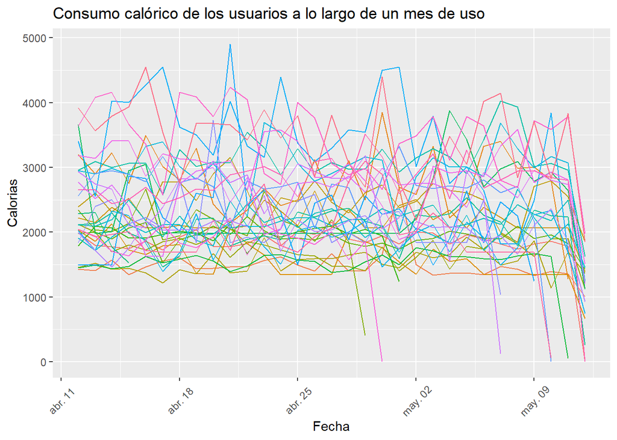

```r
ggplot(Actividad_D_lite, aes(x=Fecha,y=Calorias,group=Id,color=Id)) +
  geom_line(show.legend = FALSE) +
  theme(axis.text.x = element_text(angle=45,vjust=0.5,hjust=0.5)) +
  labs(title = "Consumo calórico de los usuarios a lo largo de un mes de uso")
```

Seguidamente obtenemos la misma gráfica pero desglosada por usuario para una mejor visualización

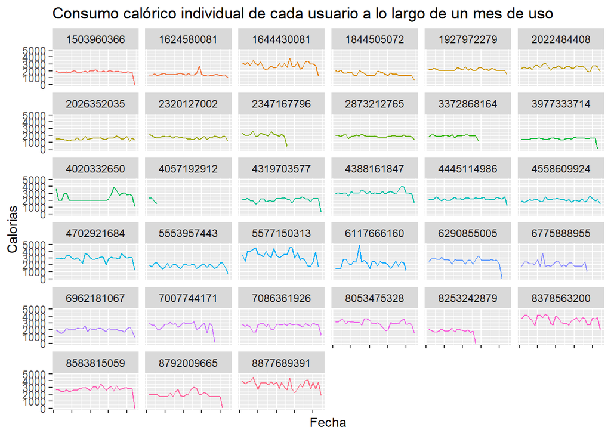

```r
ggplot(Actividad_D_lite,aes(x=Fecha,y=Calorias,group=Id,color=Id)) +
  geom_line(show.legend = FALSE) +
  theme(axis.text.x = element_blank()) +
  facet_wrap(~ Id) +
  labs(title = "Consumo calórico individual de cada usuario a lo largo de un mes de uso")
```

Las gráficas anteriores sugieren en la generalidad de los usuarios estudiados una tendencia estable de consumo calórico, con un marcado descenso de actividad física hacia final del mes. Este descenso podría estar relacionado con un descenso de motivación conforme transcurren los días de actividad.

##### Distancia recorrida por los usuarios a lo largo del mes estudiado

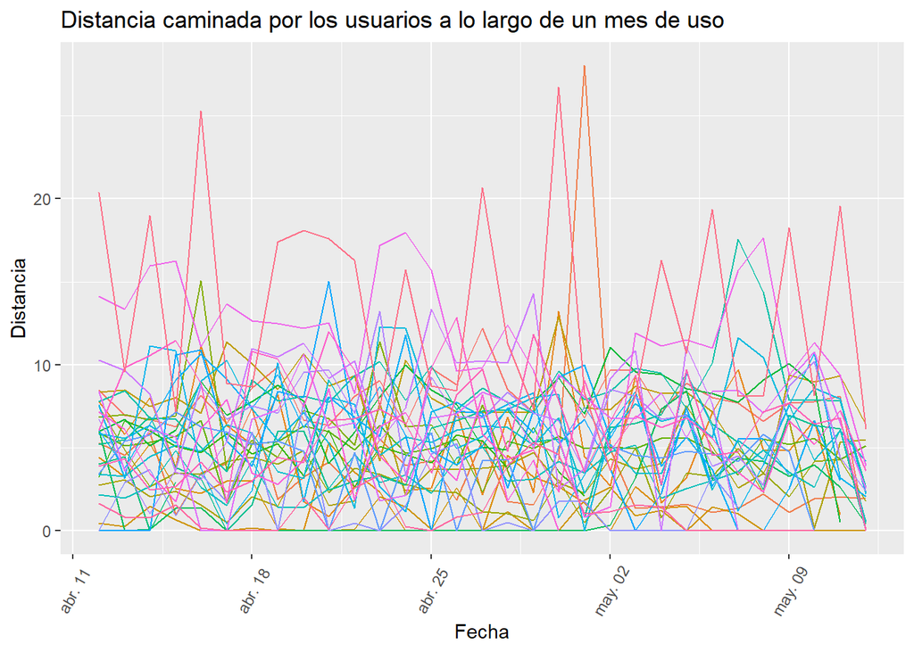

```r
ggplot(Actividad_D_lite, aes(x=Fecha,y=Distancia,group=Id,color=Id)) +
  geom_line(show.legend = FALSE) +
  theme(axis.text.x = element_text(angle=60,vjust=0.5,hjust=0.5)) +
  labs(title="Distancia caminada por los usuarios a lo largo de un mes de uso")
```

A lo largo del mes se observa una cierta periodicidad de altos y bajos a lo largo del mes registrado y a través de los casos registrados, pero con una tendencia estable.

Para una mejor visualización, obtendremos las distancias desgrosadas por usuario.

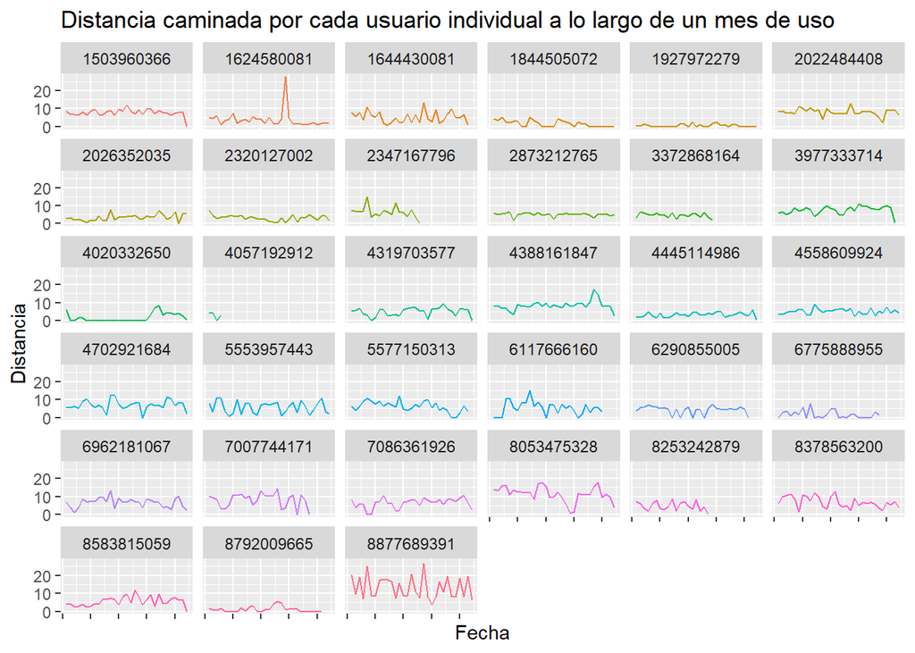

```r
ggplot(Actividad_D_lite,aes(x=Fecha,y=Distancia,group=Id,color=Id)) +
  geom_line(show.legend = FALSE) +
  theme(axis.text.x = element_blank()) +
  facet_wrap(~ Id) +
  labs(title="Distancia caminada por cada usuario individual a lo largo de un mes de uso")
```

En base a lo anterior podemos decir que, en general, los usuarios de Fitbit mantienen un nivel de actividad constante a lo largo del tiempo.

##### ¿Están relacionados el consumo calórico y la distancia que caminan los usuarios?

El fundamento de esta pregunta es intentar descubrir si la quema de calorías se produce a razón de caminar o de ejercicio físico.

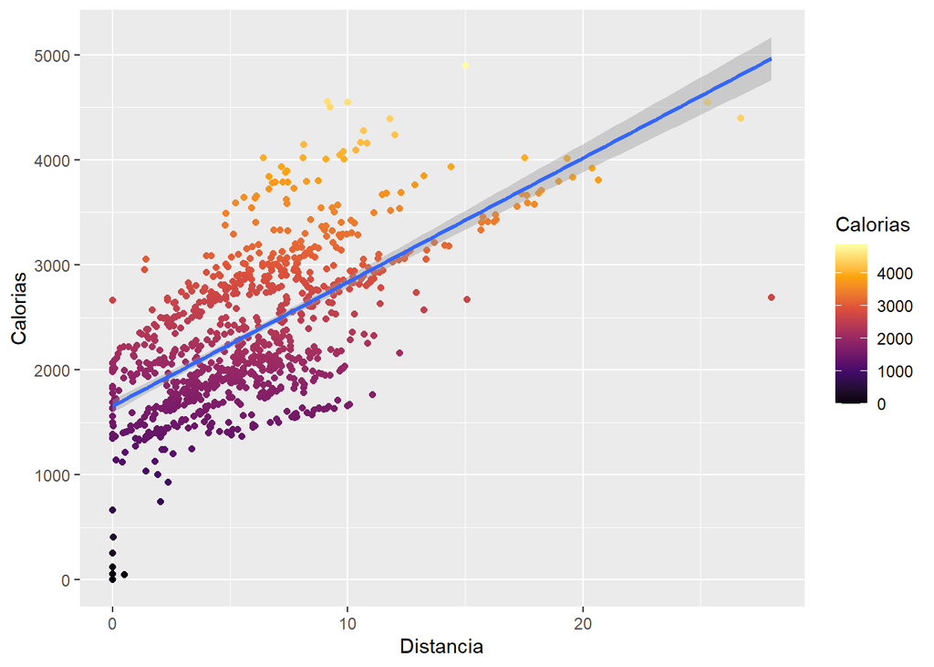

```r
ggplot(Actividad_D_lite,aes(x=Distancia,y=Calorias)) +
  geom_point(aes(color = Calorias)) +
  scale_color_viridis_c(option = "inferno") +
  geom_smooth(method = lm)
```

### B. Segundo set de datos: calorías registradas por hora

#### 1. Orden y limpieza

El set de datos llamado “hourlyCalories_merged.csv” hace un registro intensivo de observaciones de consumo calórico por hora y por día, del cual podemos obtener un valioso conjunto de datos.

Por un lado, podemos obtener el consumo de calorías por hora para intentar comprender qué nivel de actividad registran los usuarios a lo largo del día. Y por el otro, aproximar cómo es el nivel de actividad a lo largo de la semana.

Como primer paso, daremos un vistazo a los datos:

```r
str(read.csv("hourlyCalories_merged.csv"))
```

```
## 'data.frame':    22099 obs. of  3 variables:
##  $ Id          : num  1.5e+09 1.5e+09 1.5e+09 1.5e+09 1.5e+09 ...
##  $ ActivityHour: chr  "4/12/2016 12:00:00 AM" "4/12/2016 1:00:00 AM" "4/12/2016 2:00:00 AM" "4/12/2016 3:00:00 AM" ...
##  $ Calories    : int  81 61 59 47 48 48 48 47 68 141 ...
```

Acá nos encontramos con la misma limitación de formato. Con lo cual, repetimos el proceso del set de datos anterior, con la diferencia de que esta vez, separaremos la fecha en diferentes columnas para obtener información útil para nuestro análisis: hora, fecha y día de la semana. A este último, a su vez, lo recodificaremos para que sea más fácil de leer, puesto que R identifica los días de la semana con números, marcando el primer día con un 1.

```r
Calorias_H_D <- read.csv("hourlyCalories_merged.csv")
str(Calorias_H_D)
```

```
## 'data.frame':    22099 obs. of  3 variables:
##  $ Id          : num  1.5e+09 1.5e+09 1.5e+09 1.5e+09 1.5e+09 ...
##  $ ActivityHour: chr  "4/12/2016 12:00:00 AM" "4/12/2016 1:00:00 AM" "4/12/2016 2:00:00 AM" "4/12/2016 3:00:00 AM" ...
##  $ Calories    : int  81 61 59 47 48 48 48 47 68 141 ...
```

```r
Calorias_H_D <- Calorias_H_D %>%
  mutate(ActivityHour = mdy_hms(ActivityHour),
         time=as_hms(ActivityHour),
         date=as_date(ActivityHour),
         wday=wday(ActivityHour)) %>%
  mutate(Id = factor(Id),wday=factor(wday),wday=recode(wday,
                                                       "1" = "Domingo",
                                                       "2" = "Lunes",
                                                       "3" = "Martes",
                                                       "4" = "Miercoles",
                                                       "5" = "Jueves",
                                                       "6" = "Viernes",
                                                       "7" = "Sabado"))
```

Ahora que tenemos los datos apropiadamente formateados, prepararemos algunos data frames simplificados para cotejar las variables que nos interesan:

```r
Calorias_H <- Calorias_H_D %>%
  select(Id, Calories, time)
```

```r
Calorias_H <- Calorias_H %>%
  rename(Calorias=Calories,Hora=time)
```

```r
Calorias_D <- Calorias_H_D %>%
  select(Id, Calories, wday) %>%
  arrange(wday)
```

```r
Calorias_D <- Calorias_D %>%
  rename(Calorias = Calories, Dia_semana=wday)
```

En este punto lo que haremos será agrupar las quemas calóricas que se sucedieron en una misma hora, para poder observar a qué horas se registra mayor cantidad de actividad física entre todos los usuarios.

```r
Calorias_H_lite <- aggregate(Calorias_H$Calorias, by=list(Hora=Calorias_H$Hora), FUN=sum)
```

Luego, renombraremos esta tabla para leerla mejor.

```r
Calorias_H_lite <- Calorias_H_lite %>%
  rename(Calorias_totales=x)
```

Ahora agruparemos las quemas calóricas que se sucedieron en un mismo día de la semana para observar en qué día se observa mayor cantidad física.

```r
Calorias_D_lite <- aggregate(Calorias_D$Calorias, by=list(Dia_de_la_semana=Calorias_D$Dia_semana), FUN=sum)
```

Al igual que la tabla anterior, la renombraremos.

```r
Calorias_D_lite <- Calorias_D_lite %>%
  rename(Calorias_totales=x)
```

#### 2. Análisis descriptivo y visualizaciones

Teniendo las tablas anteriores, procedemos a hacer las gráficas.

##### Consumo calórico versus hora del día

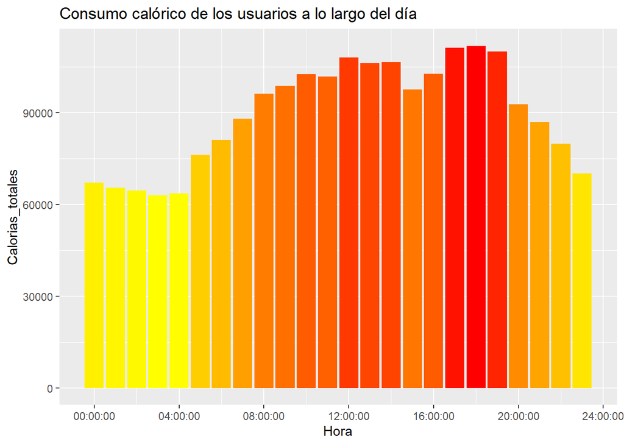

```r
ggplot(Calorias_H_lite,aes(x=Hora,y=Calorias_totales,fill=Calorias_totales)) +
  geom_bar(stat = "identity", show.legend = FALSE) +
  labs(title = "Consumo calórico de los usuarios a lo largo del día") +
  scale_fill_gradient(low = "yellow",high="red")
```

De lo anterior inferimos que los usuarios tienden a realizar actividad con mayor frecuencia durante la tarde, más precisamente entre las 12 y las 19 horas.

##### Consumo calórico versus día de la semana

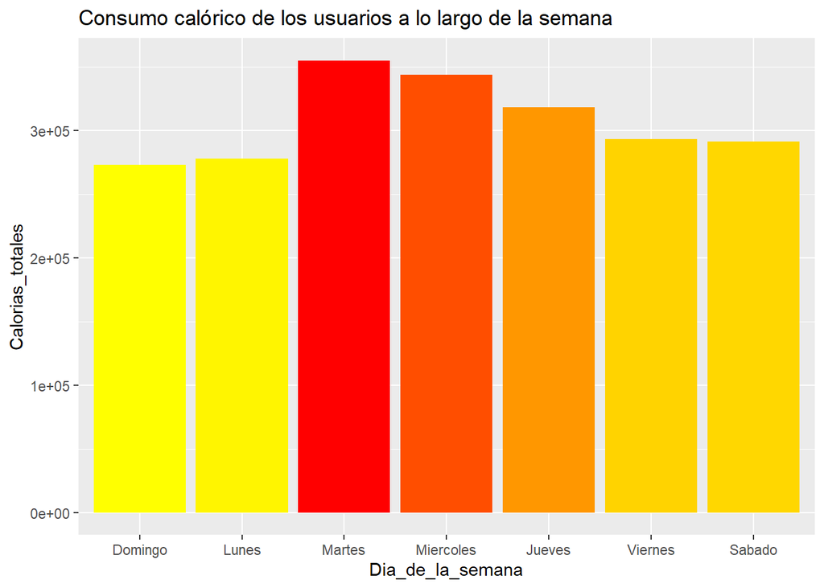

```r
ggplot(Calorias_D_lite,aes(x=Dia_de_la_semana,y=Calorias_totales,fill=Calorias_totales)) +
  geom_bar(stat = "identity", show.legend = FALSE) +
  labs(title = "Consumo calórico de los usuarios a lo largo de la semana") +
  scale_fill_gradient(low = "yellow",high="red")
```

A su vez, podemos observar que la mayor cantidad de consumo calórico se registra durante la mitad de la semana, entre los martes y los jueves, dejando los fines de semana con menos actividad física.

### C. Tercer set de datos: pasos registrados por hora

Siguiendo la misma secuencia que hicimos con las calorías registradas por hora, cotejaremos los pasos a partir del registro de observaciones llamado “hourlySteps_merged.csv” para corroborar en qué días de la semana se registra mayor distancia caminada y en cuales no. De esta manera podremos aproximar con mayor grado de exactitud si la actividad calórica registrada proviene del acto de caminar o del acto de ejercitar propiamente dicho.

#### 1. Orden y limpieza

```r
str(read.csv("hourlySteps_merged.csv"))
```

```
## 'data.frame':    22099 obs. of  3 variables:
##  $ Id          : num  1.5e+09 1.5e+09 1.5e+09 1.5e+09 1.5e+09 ...
##  $ ActivityHour: chr  "4/12/2016 12:00:00 AM" "4/12/2016 1:00:00 AM" "4/12/2016 2:00:00 AM" "4/12/2016 3:00:00 AM" ...
##  $ StepTotal   : int  373 160 151 0 0 0 0 0 250 1864 ...
```

Haremos el mismo proceso de formateo que en el paso B.

```r
Pasos_H_D <- read.csv("hourlySteps_merged.csv")
str(Pasos_H_D)
```

```
## 'data.frame':    22099 obs. of  3 variables:
##  $ Id          : num  1.5e+09 1.5e+09 1.5e+09 1.5e+09 1.5e+09 ...
##  $ ActivityHour: chr  "4/12/2016 12:00:00 AM" "4/12/2016 1:00:00 AM" "4/12/2016 2:00:00 AM" "4/12/2016 3:00:00 AM" ...
##  $ StepTotal   : int  373 160 151 0 0 0 0 0 250 1864 ...
```

```r
Pasos_H_D <- Pasos_H_D %>%
  mutate(ActivityHour = mdy_hms(ActivityHour),
         time=as_hms(ActivityHour),
         date=as_date(ActivityHour),
         wday=wday(ActivityHour)) %>%
  mutate(Id = factor(Id),wday=factor(wday),wday=recode(wday,
                                                       "1" = "Domingo",
                                                       "2" = "Lunes",
                                                       "3" = "Martes",
                                                       "4" = "Miercoles",
                                                       "5" = "Jueves",
                                                       "6" = "Viernes",
                                                       "7" = "Sabado"))
```

Seleccionamos y renombramos:

```r
Pasos_H <- Pasos_H_D %>%
  select(Id, StepTotal, time)
```

```r
Pasos_H <- Pasos_H %>%
  rename(Pasos=StepTotal,Hora=time)
```

```r
Pasos_D <- Pasos_H_D %>%
  select(Id, StepTotal, wday) %>%
  arrange(wday)
```

```r
Pasos_D <- Pasos_D %>%
  rename(Pasos = StepTotal, Dia_semana=wday)
```

Agrupamos los pasos caminados que se dieron en una misma hora por un lado, y en un mismo día por el otro.

```r
Pasos_H_comb <- aggregate(Pasos_H$Pasos, by=list(Hora=Pasos_H$Hora), FUN=sum)
```

```r
Pasos_D_comb <- aggregate(Pasos_D$Pasos, by=list(Hora=Pasos_D$Dia_semana), FUN=sum)
```

Para identificar las variables, renombramos:

```r
Pasos_H_comb <- Pasos_H_comb %>%
  rename(Pasos_totales=x)
```

```r
Pasos_D_comb <- Pasos_D_comb %>%
  rename(Pasos_totales=x)
```

#### 2. Análisis descriptivo y visualizaciones

Por último, visualizamos:

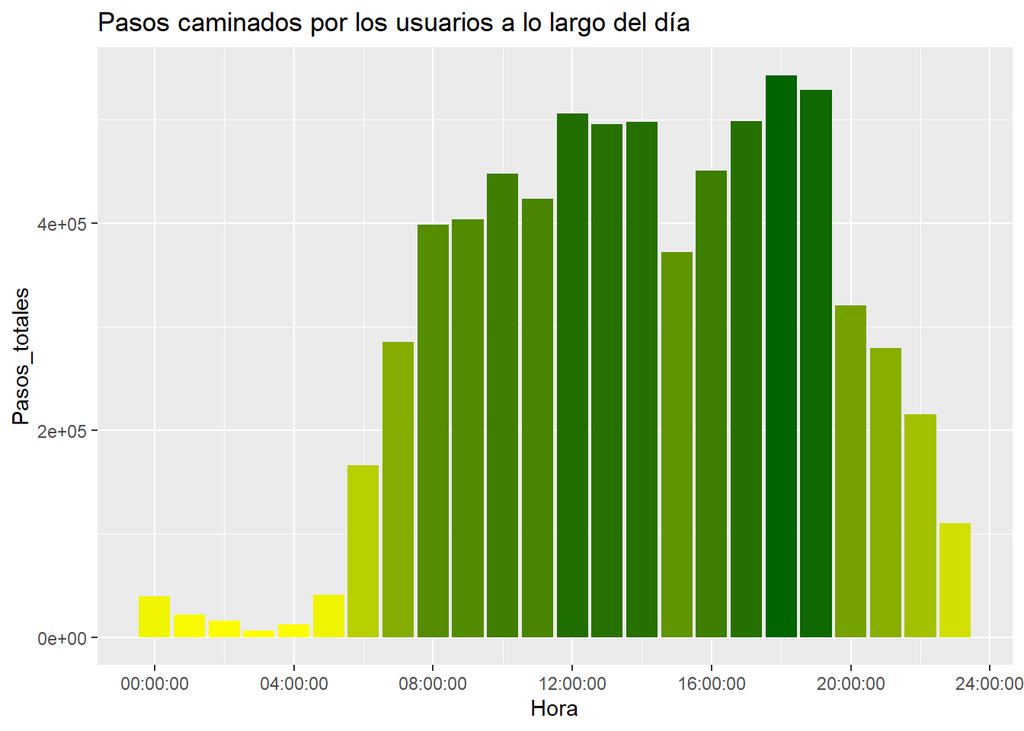

```r
ggplot(Pasos_H_comb,aes(x=Hora,y=Pasos_totales,fill=Pasos_totales)) +
  geom_bar(stat = "identity", show.legend = FALSE) +
  labs(title = "Pasos caminados por los usuarios a lo largo del día") +
  scale_fill_gradient(low = "yellow",high="darkgreen")
```

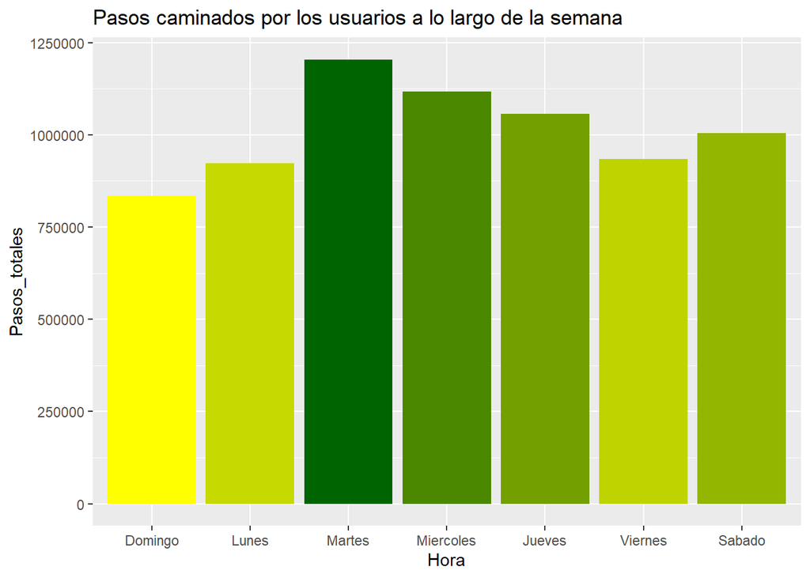

```r
ggplot(Pasos_D_comb,aes(x=Hora,y=Pasos_totales,fill=Pasos_totales)) +
  geom_bar(stat = "identity", show.legend = FALSE) +
  labs(title = "Pasos caminados por los usuarios a lo largo de la semana") +
  scale_fill_gradient(low = "yellow",high="darkgreen")
```

Los gráficos anteriores parecen indicar que los usuarios son de caminar más durante días de semana, especialmente en horarios laborales entre la mañana y la tarde. Esto podría señalar que mayoritariamente caminan como medio de transporte y no como ejercicio.

# Respondiendo a las preguntas

Habiendo hecho un análisis con lo que consideramos los datos de mayor valor, procedemos a contestar las preguntas que motivaron este proceso.

## ¿Cuáles son algunas tendencias en el uso de dispositivos smart?

No obstante, a pesar de los altibajos registrados a lo largo del mes, suelen mantener un nivel constante de actividad. Los datos parecen indicar que realizan sus actividades físicas con mayor intensidad durante la semana, con un mayor nivel particularmente en horario laboral.

Todo parece indicar que existe un cierto nivel de correlación entre las calorías utilizadas, las distancias y los pasos, lo que sustenta la afirmación de que los usuarios caminan mayoritariamente como medio de transporte.

## ¿Cómo se podrían aplicar estas tendencias a los usuarios de Bellabeat?

Estas tendencias podrían aplicarse en función de orientar un proceso de mejora de los relevamientos de datos realizados por los dispositivos y servicios de Bellebeat, poniendo a disposición del usuario la información producida por sus actividades de forma intuitiva, ágil y atractiva en pos de orientar su rutina diaria hacia resultados deseados, en plena concordancia con las normativas vigentes en materia de privacidad y uso responsable de datos.

## ¿Cómo podrían estas tendencias ayudar a influenciar la estrategia de Marketing de Bellabeat?

Estas tendencias ayudan a elegir de manera efectiva un avatar específico del público femenino interesado en el fitness, la nutrición y el bienestar general, el cual al mismo tiempo utiliza dispositivos inteligentes habitualmente ya sea por trabajo y/o por ocio.

Podría ser de especial interés elaborar estrategias de contenido en redes sociales diseñadas para el público que consume contenido fitness con regularidad, en forma de podcasts, reels, tips nutricionales y similares.

Sin embargo, tampoco se debe destacar la publicidad gráfica en cartelería urbana, haciendo foco principalmente en lugares de alta actividad peatonal, espacios recreativos y deportivos.

El plan de acción sugerido entonces es:

- Contenido y marketing en redes sociales en forma de reels, fotos, y podcasts con contenido fitness
- Publicidad gráfica con estadísticas reales sobre los resultados obtenidos gracias a Bellabeat
- Publicidad en buscadores